# Risk Factor Analysis

## Outcome Variable

**Outcome Variable:** ever_swasted

## Predictor Variables

**Intervention Variable:** hdlvry

**Adjustment Set:**

- arm
- sex
- W_mage
- meducyrs
- feducyrs
- hhwealth_quart
- single
- W_nrooms
- brthmon
- W_parity
- impsan
- delta_W_mage
- delta_meducyrs
- delta_feducyrs
- delta_hhwealth_quart
- delta_single
- delta_W_nrooms
- delta_brthmon
- delta_W_parity
- delta_impsan

## Stratifying Variables

The analysis was stratified on these variable(s):

- agecat
- studyid
- country

## Data Summary

| agecat | studyid | country | hdlvry | ever_swasted | n_cell | n |
| --- | --- | --- | --- | --- | --- | --- |
| 0-24 months (no birth wast) | CMC-V-BCS-2002 | INDIA | 0 | 0 | 303 | 365 |
| 0-24 months (no birth wast) | CMC-V-BCS-2002 | INDIA | 0 | 1 | 54 | 365 |
| 0-24 months (no birth wast) | CMC-V-BCS-2002 | INDIA | 1 | 0 | 7 | 365 |
| 0-24 months (no birth wast) | CMC-V-BCS-2002 | INDIA | 1 | 1 | 1 | 365 |
| 0-24 months (no birth wast) | COHORTS | INDIA | 0 | 0 | 2916 | 4904 |
| 0-24 months (no birth wast) | COHORTS | INDIA | 0 | 1 | 114 | 4904 |
| 0-24 months (no birth wast) | COHORTS | INDIA | 1 | 0 | 1743 | 4904 |
| 0-24 months (no birth wast) | COHORTS | INDIA | 1 | 1 | 131 | 4904 |
| 0-24 months (no birth wast) | EE | PAKISTAN | 0 | 0 | 210 | 375 |
| 0-24 months (no birth wast) | EE | PAKISTAN | 0 | 1 | 42 | 375 |
| 0-24 months (no birth wast) | EE | PAKISTAN | 1 | 0 | 100 | 375 |
| 0-24 months (no birth wast) | EE | PAKISTAN | 1 | 1 | 23 | 375 |
| 0-24 months (no birth wast) | GMS-Nepal | NEPAL | 0 | 0 | 132 | 613 |
| 0-24 months (no birth wast) | GMS-Nepal | NEPAL | 0 | 1 | 16 | 613 |
| 0-24 months (no birth wast) | GMS-Nepal | NEPAL | 1 | 0 | 361 | 613 |
| 0-24 months (no birth wast) | GMS-Nepal | NEPAL | 1 | 1 | 104 | 613 |
| 0-24 months (no birth wast) | IRC | INDIA | 0 | 0 | 326 | 409 |
| 0-24 months (no birth wast) | IRC | INDIA | 0 | 1 | 75 | 409 |
| 0-24 months (no birth wast) | IRC | INDIA | 1 | 0 | 6 | 409 |
| 0-24 months (no birth wast) | IRC | INDIA | 1 | 1 | 2 | 409 |
| 0-24 months (no birth wast) | JiVitA-3 | BANGLADESH | 0 | 0 | 39 | 346 |
| 0-24 months (no birth wast) | JiVitA-3 | BANGLADESH | 0 | 1 | 2 | 346 |
| 0-24 months (no birth wast) | JiVitA-3 | BANGLADESH | 1 | 0 | 289 | 346 |
| 0-24 months (no birth wast) | JiVitA-3 | BANGLADESH | 1 | 1 | 16 | 346 |
| 0-24 months (no birth wast) | JiVitA-4 | BANGLADESH | 0 | 0 | 1129 | 4480 |
| 0-24 months (no birth wast) | JiVitA-4 | BANGLADESH | 0 | 1 | 38 | 4480 |
| 0-24 months (no birth wast) | JiVitA-4 | BANGLADESH | 1 | 0 | 3144 | 4480 |
| 0-24 months (no birth wast) | JiVitA-4 | BANGLADESH | 1 | 1 | 169 | 4480 |
| 0-24 months (no birth wast) | NIH-Crypto | BANGLADESH | 0 | 0 | 573 | 754 |
| 0-24 months (no birth wast) | NIH-Crypto | BANGLADESH | 0 | 1 | 14 | 754 |

[output cut: 114 more lines]

The following strata were considered:

- agecat: 0-24 months (no birth wast), studyid: CMC-V-BCS-2002, country: INDIA
- agecat: 0-24 months (no birth wast), studyid: COHORTS, country: INDIA
- agecat: 0-24 months (no birth wast), studyid: EE, country: PAKISTAN
- agecat: 0-24 months (no birth wast), studyid: GMS-Nepal, country: NEPAL
- agecat: 0-24 months (no birth wast), studyid: IRC, country: INDIA
- agecat: 0-24 months (no birth wast), studyid: JiVitA-3, country: BANGLADESH
- agecat: 0-24 months (no birth wast), studyid: JiVitA-4, country: BANGLADESH
- agecat: 0-24 months (no birth wast), studyid: NIH-Crypto, country: BANGLADESH
- agecat: 0-24 months (no birth wast), studyid: PROVIDE, country: BANGLADESH
- agecat: 0-24 months (no birth wast), studyid: SAS-CompFeed, country: INDIA
- agecat: 0-24 months (no birth wast), studyid: SAS-FoodSuppl, country: INDIA
- agecat: 0-24 months (no birth wast), studyid: TanzaniaChild2, country: TANZANIA, UNITED REPUBLIC OF
- agecat: 0-6 months (no birth wast), studyid: CMC-V-BCS-2002, country: INDIA
- agecat: 0-6 months (no birth wast), studyid: COHORTS, country: INDIA
- agecat: 0-6 months (no birth wast), studyid: EE, country: PAKISTAN
- agecat: 0-6 months (no birth wast), studyid: GMS-Nepal, country: NEPAL
- agecat: 0-6 months (no birth wast), studyid: IRC, country: INDIA
- agecat: 0-6 months (no birth wast), studyid: JiVitA-3, country: BANGLADESH
- agecat: 0-6 months (no birth wast), studyid: JiVitA-4, country: BANGLADESH
- agecat: 0-6 months (no birth wast), studyid: NIH-Crypto, country: BANGLADESH
- agecat: 0-6 months (no birth wast), studyid: PROVIDE, country: BANGLADESH
- agecat: 0-6 months (no birth wast), studyid: SAS-CompFeed, country: INDIA
- agecat: 0-6 months (no birth wast), studyid: SAS-FoodSuppl, country: INDIA
- agecat: 0-6 months (no birth wast), studyid: TanzaniaChild2, country: TANZANIA, UNITED REPUBLIC OF
- agecat: 6-24 months, studyid: CMC-V-BCS-2002, country: INDIA
- agecat: 6-24 months, studyid: COHORTS, country: INDIA
- agecat: 6-24 months, studyid: EE, country: PAKISTAN
- agecat: 6-24 months, studyid: GMS-Nepal, country: NEPAL
- agecat: 6-24 months, studyid: IRC, country: INDIA
- agecat: 6-24 months, studyid: JiVitA-3, country: BANGLADESH
- agecat: 6-24 months, studyid: JiVitA-4, country: BANGLADESH
- agecat: 6-24 months, studyid: NIH-Crypto, country: BANGLADESH
- agecat: 6-24 months, studyid: PROVIDE, country: BANGLADESH
- agecat: 6-24 months, studyid: SAS-CompFeed, country: INDIA
- agecat: 6-24 months, studyid: SAS-FoodSuppl, country: INDIA
- agecat: 6-24 months, studyid: TanzaniaChild2, country: TANZANIA, UNITED REPUBLIC OF

### Dropped Strata

Some strata were dropped due to rare outcomes:

- agecat: 0-24 months (no birth wast), studyid: CMC-V-BCS-2002, country: INDIA
- agecat: 0-24 months (no birth wast), studyid: IRC, country: INDIA
- agecat: 0-24 months (no birth wast), studyid: JiVitA-3, country: BANGLADESH
- agecat: 0-24 months (no birth wast), studyid: TanzaniaChild2, country: TANZANIA, UNITED REPUBLIC OF
- agecat: 0-6 months (no birth wast), studyid: CMC-V-BCS-2002, country: INDIA
- agecat: 0-6 months (no birth wast), studyid: IRC, country: INDIA
- agecat: 0-6 months (no birth wast), studyid: JiVitA-3, country: BANGLADESH
- agecat: 0-6 months (no birth wast), studyid: NIH-Crypto, country: BANGLADESH
- agecat: 0-6 months (no birth wast), studyid: PROVIDE, country: BANGLADESH
- agecat: 0-6 months (no birth wast), studyid: SAS-CompFeed, country: INDIA
- agecat: 0-6 months (no birth wast), studyid: SAS-FoodSuppl, country: INDIA
- agecat: 0-6 months (no birth wast), studyid: TanzaniaChild2, country: TANZANIA, UNITED REPUBLIC OF
- agecat: 6-24 months, studyid: CMC-V-BCS-2002, country: INDIA
- agecat: 6-24 months, studyid: IRC, country: INDIA
- agecat: 6-24 months, studyid: JiVitA-3, country: BANGLADESH
- agecat: 6-24 months, studyid: TanzaniaChild2, country: TANZANIA, UNITED REPUBLIC OF

## Methods Detail

We’re interested in the causal parameters $E[Y_a]$ for all values of $a \in \mathcal{A}$. These parameters represent the mean outcome if, possibly contrary to fact, we intervened to set all units to have $A=a$. Under the randomization and positivity assumptions, these are identified by the statistical parameters $\psi_a=E_W[E_{Y|A,W}(Y|A=a,W)]$. In addition, we’re interested in the mean of $Y$, $E[Y]$ under no intervention (the observed mean). We will estimate these parameters by using SuperLearner to fit the relevant likelihood factors – $E_{Y|A,W}(Y|A=a,W)$ and $p(A=a|W)$, and then updating our likelihood fit using a joint TMLE.

For unadjusted analyses ($W=\{\}$), initial likelihoods were estimated using Lrnr_glm to estimate the simple $E(Y|A)$ and Lrnr_mean to estimate $p(A)$. For adjusted analyses, a small library containing Lrnr_glmnet, Lrnr_xgboost, and Lrnr_mean was used.

Having estimated these parameters, we will then use the delta method to estimate relative risks and attributable risks relative to a prespecified baseline level of $A$.

# Results Detail

## Results Plots

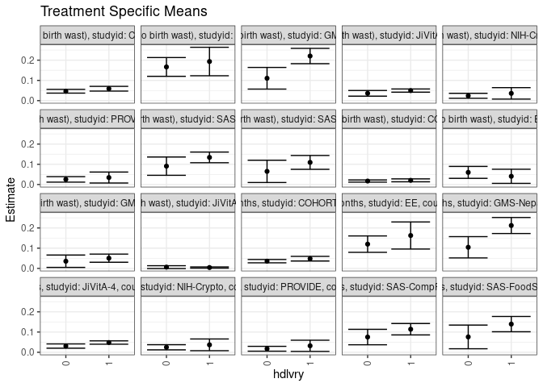

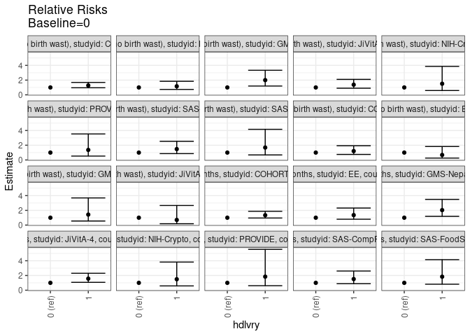

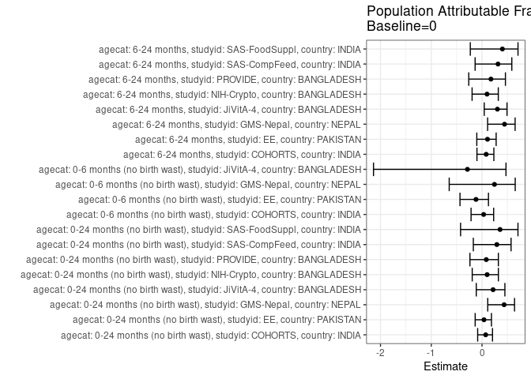

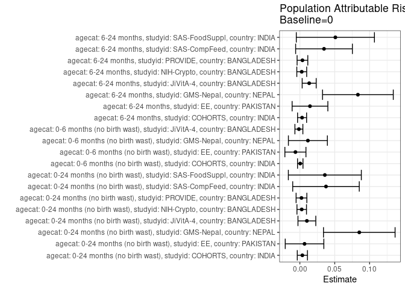

## Results Table

### Parameter: TSM

| agecat | studyid | country | intervention_level | baseline_level | estimate | ci_lower | ci_upper |
| --- | --- | --- | --- | --- | --- | --- | --- |
| 0-24 months (no birth wast) | COHORTS | INDIA | 0 | NA | 0.0463719 | 0.0371112 | 0.0556326 |
| 0-24 months (no birth wast) | COHORTS | INDIA | 1 | NA | 0.0588852 | 0.0472084 | 0.0705621 |
| 0-24 months (no birth wast) | EE | PAKISTAN | 0 | NA | 0.1666219 | 0.1202050 | 0.2130387 |
| 0-24 months (no birth wast) | EE | PAKISTAN | 1 | NA | 0.1934088 | 0.1229445 | 0.2638731 |
| 0-24 months (no birth wast) | GMS-Nepal | NEPAL | 0 | NA | 0.1105587 | 0.0570129 | 0.1641044 |
| 0-24 months (no birth wast) | GMS-Nepal | NEPAL | 1 | NA | 0.2205537 | 0.1826158 | 0.2584916 |
| 0-24 months (no birth wast) | JiVitA-4 | BANGLADESH | 0 | NA | 0.0361368 | 0.0221277 | 0.0501459 |
| 0-24 months (no birth wast) | JiVitA-4 | BANGLADESH | 1 | NA | 0.0496268 | 0.0417228 | 0.0575307 |
| 0-24 months (no birth wast) | NIH-Crypto | BANGLADESH | 0 | NA | 0.0238501 | 0.0114986 | 0.0362016 |
| 0-24 months (no birth wast) | NIH-Crypto | BANGLADESH | 1 | NA | 0.0359281 | 0.0076826 | 0.0641737 |
| 0-24 months (no birth wast) | PROVIDE | BANGLADESH | 0 | NA | 0.0253411 | 0.0117315 | 0.0389507 |
| 0-24 months (no birth wast) | PROVIDE | BANGLADESH | 1 | NA | 0.0344828 | 0.0073514 | 0.0616141 |
| 0-24 months (no birth wast) | SAS-CompFeed | INDIA | 0 | NA | 0.0908026 | 0.0455569 | 0.1360483 |
| 0-24 months (no birth wast) | SAS-CompFeed | INDIA | 1 | NA | 0.1340464 | 0.1076190 | 0.1604739 |
| 0-24 months (no birth wast) | SAS-FoodSuppl | INDIA | 0 | NA | 0.0649351 | 0.0098275 | 0.1200426 |
| 0-24 months (no birth wast) | SAS-FoodSuppl | INDIA | 1 | NA | 0.1093750 | 0.0751355 | 0.1436145 |
| 0-6 months (no birth wast) | COHORTS | INDIA | 0 | NA | 0.0171132 | 0.0116766 | 0.0225499 |
| 0-6 months (no birth wast) | COHORTS | INDIA | 1 | NA | 0.0206069 | 0.0134286 | 0.0277851 |
| 0-6 months (no birth wast) | EE | PAKISTAN | 0 | NA | 0.0600000 | 0.0305218 | 0.0894782 |
| 0-6 months (no birth wast) | EE | PAKISTAN | 1 | NA | 0.0406504 | 0.0057043 | 0.0755966 |
| 0-6 months (no birth wast) | GMS-Nepal | NEPAL | 0 | NA | 0.0354610 | 0.0049091 | 0.0660129 |
| 0-6 months (no birth wast) | GMS-Nepal | NEPAL | 1 | NA | 0.0505495 | 0.0304029 | 0.0706960 |
| 0-6 months (no birth wast) | JiVitA-4 | BANGLADESH | 0 | NA | 0.0061947 | -0.0008760 | 0.0132654 |
| 0-6 months (no birth wast) | JiVitA-4 | BANGLADESH | 1 | NA | 0.0043303 | 0.0013560 | 0.0073047 |
| 6-24 months | COHORTS | INDIA | 0 | NA | 0.0358285 | 0.0275905 | 0.0440665 |
| 6-24 months | COHORTS | INDIA | 1 | NA | 0.0479998 | 0.0364959 | 0.0595036 |
| 6-24 months | EE | PAKISTAN | 0 | NA | 0.1198973 | 0.0793587 | 0.1604359 |
| 6-24 months | EE | PAKISTAN | 1 | NA | 0.1626161 | 0.0956599 | 0.2295723 |
| 6-24 months | GMS-Nepal | NEPAL | 0 | NA | 0.1043918 | 0.0516887 | 0.1570950 |
| 6-24 months | GMS-Nepal | NEPAL | 1 | NA | 0.2121147 | 0.1725026 | 0.2517268 |
| 6-24 months | JiVitA-4 | BANGLADESH | 0 | NA | 0.0307078 | 0.0201495 | 0.0412661 |
| 6-24 months | JiVitA-4 | BANGLADESH | 1 | NA | 0.0482219 | 0.0400033 | 0.0564405 |
| 6-24 months | NIH-Crypto | BANGLADESH | 0 | NA | 0.0246914 | 0.0119094 | 0.0374733 |
| 6-24 months | NIH-Crypto | BANGLADESH | 1 | NA | 0.0368098 | 0.0078837 | 0.0657359 |
| 6-24 months | PROVIDE | BANGLADESH | 0 | NA | 0.0174292 | 0.0054476 | 0.0294108 |
| 6-24 months | PROVIDE | BANGLADESH | 1 | NA | 0.0320513 | 0.0043890 | 0.0597136 |
| 6-24 months | SAS-CompFeed | INDIA | 0 | NA | 0.0752933 | 0.0371039 | 0.1134827 |
| 6-24 months | SAS-CompFeed | INDIA | 1 | NA | 0.1139707 | 0.0857988 | 0.1421426 |
| 6-24 months | SAS-FoodSuppl | INDIA | 0 | NA | 0.0759494 | 0.0174589 | 0.1344399 |
| 6-24 months | SAS-FoodSuppl | INDIA | 1 | NA | 0.1393189 | 0.1015083 | 0.1771295 |

### Parameter: E(Y)

| agecat | studyid | country | intervention_level | baseline_level | estimate | ci_lower | ci_upper |
| --- | --- | --- | --- | --- | --- | --- | --- |
| 0-24 months (no birth wast) | COHORTS | INDIA | NA | NA | 0.0499592 | 0.0438611 | 0.0560573 |
| 0-24 months (no birth wast) | EE | PAKISTAN | NA | NA | 0.1733333 | 0.1349698 | 0.2116969 |
| 0-24 months (no birth wast) | GMS-Nepal | NEPAL | NA | NA | 0.1957586 | 0.1643227 | 0.2271945 |
| 0-24 months (no birth wast) | JiVitA-4 | BANGLADESH | NA | NA | 0.0462054 | 0.0395696 | 0.0528411 |
| 0-24 months (no birth wast) | NIH-Crypto | BANGLADESH | NA | NA | 0.0265252 | 0.0150478 | 0.0380026 |
| 0-24 months (no birth wast) | PROVIDE | BANGLADESH | NA | NA | 0.0276565 | 0.0153851 | 0.0399279 |
| 0-24 months (no birth wast) | SAS-CompFeed | INDIA | NA | NA | 0.1282680 | 0.1041743 | 0.1523617 |
| 0-24 months (no birth wast) | SAS-FoodSuppl | INDIA | NA | NA | 0.1007557 | 0.0711091 | 0.1304022 |
| 0-6 months (no birth wast) | COHORTS | INDIA | NA | NA | 0.0176757 | 0.0138363 | 0.0215150 |
| 0-6 months (no birth wast) | EE | PAKISTAN | NA | NA | 0.0536193 | 0.0307280 | 0.0765106 |
| 0-6 months (no birth wast) | GMS-Nepal | NEPAL | NA | NA | 0.0469799 | 0.0299780 | 0.0639817 |
| 0-6 months (no birth wast) | JiVitA-4 | BANGLADESH | NA | NA | 0.0048132 | 0.0019592 | 0.0076672 |
| 6-24 months | COHORTS | INDIA | NA | NA | 0.0390131 | 0.0335015 | 0.0445247 |
| 6-24 months | EE | PAKISTAN | NA | NA | 0.1344086 | 0.0997005 | 0.1691167 |
| 6-24 months | GMS-Nepal | NEPAL | NA | NA | 0.1876138 | 0.1549271 | 0.2203006 |
| 6-24 months | JiVitA-4 | BANGLADESH | NA | NA | 0.0440784 | 0.0374167 | 0.0507400 |
| 6-24 months | NIH-Crypto | BANGLADESH | NA | NA | 0.0273973 | 0.0155476 | 0.0392469 |
| 6-24 months | PROVIDE | BANGLADESH | NA | NA | 0.0211382 | 0.0097604 | 0.0325160 |
| 6-24 months | SAS-CompFeed | INDIA | NA | NA | 0.1099291 | 0.0842813 | 0.1355769 |
| 6-24 months | SAS-FoodSuppl | INDIA | NA | NA | 0.1268657 | 0.0942904 | 0.1594410 |

### Parameter: RR

| agecat | studyid | country | intervention_level | baseline_level | estimate | ci_lower | ci_upper |
| --- | --- | --- | --- | --- | --- | --- | --- |
| 0-24 months (no birth wast) | COHORTS | INDIA | 0 | 0 | 1.0000000 | 1.0000000 | 1.000000 |
| 0-24 months (no birth wast) | COHORTS | INDIA | 1 | 0 | 1.2698468 | 0.9588210 | 1.681764 |
| 0-24 months (no birth wast) | EE | PAKISTAN | 0 | 0 | 1.0000000 | 1.0000000 | 1.000000 |
| 0-24 months (no birth wast) | EE | PAKISTAN | 1 | 0 | 1.1607649 | 0.7331608 | 1.837762 |
| 0-24 months (no birth wast) | GMS-Nepal | NEPAL | 0 | 0 | 1.0000000 | 1.0000000 | 1.000000 |
| 0-24 months (no birth wast) | GMS-Nepal | NEPAL | 1 | 0 | 1.9949019 | 1.1928852 | 3.336142 |
| 0-24 months (no birth wast) | JiVitA-4 | BANGLADESH | 0 | 0 | 1.0000000 | 1.0000000 | 1.000000 |
| 0-24 months (no birth wast) | JiVitA-4 | BANGLADESH | 1 | 0 | 1.3733023 | 0.8999944 | 2.095523 |
| 0-24 months (no birth wast) | NIH-Crypto | BANGLADESH | 0 | 0 | 1.0000000 | 1.0000000 | 1.000000 |
| 0-24 months (no birth wast) | NIH-Crypto | BANGLADESH | 1 | 0 | 1.5064157 | 0.5876161 | 3.861855 |
| 0-24 months (no birth wast) | PROVIDE | BANGLADESH | 0 | 0 | 1.0000000 | 1.0000000 | 1.000000 |
| 0-24 months (no birth wast) | PROVIDE | BANGLADESH | 1 | 0 | 1.3607427 | 0.5248752 | 3.527735 |
| 0-24 months (no birth wast) | SAS-CompFeed | INDIA | 0 | 0 | 1.0000000 | 1.0000000 | 1.000000 |
| 0-24 months (no birth wast) | SAS-CompFeed | INDIA | 1 | 0 | 1.4762406 | 0.8608439 | 2.531570 |
| 0-24 months (no birth wast) | SAS-FoodSuppl | INDIA | 0 | 0 | 1.0000000 | 1.0000000 | 1.000000 |
| 0-24 months (no birth wast) | SAS-FoodSuppl | INDIA | 1 | 0 | 1.6843750 | 0.6817053 | 4.161797 |
| 0-6 months (no birth wast) | COHORTS | INDIA | 0 | 0 | 1.0000000 | 1.0000000 | 1.000000 |
| 0-6 months (no birth wast) | COHORTS | INDIA | 1 | 0 | 1.2041482 | 0.7514384 | 1.929596 |
| 0-6 months (no birth wast) | EE | PAKISTAN | 0 | 0 | 1.0000000 | 1.0000000 | 1.000000 |
| 0-6 months (no birth wast) | EE | PAKISTAN | 1 | 0 | 0.6775068 | 0.2517050 | 1.823624 |
| 0-6 months (no birth wast) | GMS-Nepal | NEPAL | 0 | 0 | 1.0000000 | 1.0000000 | 1.000000 |
| 0-6 months (no birth wast) | GMS-Nepal | NEPAL | 1 | 0 | 1.4254945 | 0.5516931 | 3.683270 |
| 0-6 months (no birth wast) | JiVitA-4 | BANGLADESH | 0 | 0 | 1.0000000 | 1.0000000 | 1.000000 |
| 0-6 months (no birth wast) | JiVitA-4 | BANGLADESH | 1 | 0 | 0.6990411 | 0.1835273 | 2.662593 |
| 6-24 months | COHORTS | INDIA | 0 | 0 | 1.0000000 | 1.0000000 | 1.000000 |
| 6-24 months | COHORTS | INDIA | 1 | 0 | 1.3397088 | 0.9614778 | 1.866730 |
| 6-24 months | EE | PAKISTAN | 0 | 0 | 1.0000000 | 1.0000000 | 1.000000 |
| 6-24 months | EE | PAKISTAN | 1 | 0 | 1.3562948 | 0.7954655 | 2.312527 |
| 6-24 months | GMS-Nepal | NEPAL | 0 | 0 | 1.0000000 | 1.0000000 | 1.000000 |
| 6-24 months | GMS-Nepal | NEPAL | 1 | 0 | 2.0319091 | 1.1850481 | 3.483955 |
| 6-24 months | JiVitA-4 | BANGLADESH | 0 | 0 | 1.0000000 | 1.0000000 | 1.000000 |
| 6-24 months | JiVitA-4 | BANGLADESH | 1 | 0 | 1.5703460 | 1.0721901 | 2.299953 |
| 6-24 months | NIH-Crypto | BANGLADESH | 0 | 0 | 1.0000000 | 1.0000000 | 1.000000 |
| 6-24 months | NIH-Crypto | BANGLADESH | 1 | 0 | 1.4907975 | 0.5817579 | 3.820279 |
| 6-24 months | PROVIDE | BANGLADESH | 0 | 0 | 1.0000000 | 1.0000000 | 1.000000 |
| 6-24 months | PROVIDE | BANGLADESH | 1 | 0 | 1.8389423 | 0.6100618 | 5.543223 |
| 6-24 months | SAS-CompFeed | INDIA | 0 | 0 | 1.0000000 | 1.0000000 | 1.000000 |
| 6-24 months | SAS-CompFeed | INDIA | 1 | 0 | 1.5136898 | 0.8800982 | 2.603410 |
| 6-24 months | SAS-FoodSuppl | INDIA | 0 | 0 | 1.0000000 | 1.0000000 | 1.000000 |
| 6-24 months | SAS-FoodSuppl | INDIA | 1 | 0 | 1.8343653 | 0.8107074 | 4.150568 |

### Parameter: PAR

| agecat | studyid | country | intervention_level | baseline_level | estimate | ci_lower | ci_upper |
| --- | --- | --- | --- | --- | --- | --- | --- |
| 0-24 months (no birth wast) | COHORTS | INDIA | 0 | NA | 0.0035873 | -0.0036943 | 0.0108689 |
| 0-24 months (no birth wast) | EE | PAKISTAN | 0 | NA | 0.0067115 | -0.0209578 | 0.0343807 |
| 0-24 months (no birth wast) | GMS-Nepal | NEPAL | 0 | NA | 0.0851999 | 0.0338733 | 0.1365266 |
| 0-24 months (no birth wast) | JiVitA-4 | BANGLADESH | 0 | NA | 0.0100686 | -0.0027006 | 0.0228377 |
| 0-24 months (no birth wast) | NIH-Crypto | BANGLADESH | 0 | NA | 0.0026751 | -0.0041623 | 0.0095125 |
| 0-24 months (no birth wast) | PROVIDE | BANGLADESH | 0 | NA | 0.0023153 | -0.0053782 | 0.0100089 |
| 0-24 months (no birth wast) | SAS-CompFeed | INDIA | 0 | NA | 0.0374654 | -0.0102540 | 0.0851848 |
| 0-24 months (no birth wast) | SAS-FoodSuppl | INDIA | 0 | NA | 0.0358206 | -0.0165028 | 0.0881440 |
| 0-6 months (no birth wast) | COHORTS | INDIA | 0 | NA | 0.0005624 | -0.0033340 | 0.0044589 |
| 0-6 months (no birth wast) | EE | PAKISTAN | 0 | NA | -0.0063807 | -0.0214851 | 0.0087237 |
| 0-6 months (no birth wast) | GMS-Nepal | NEPAL | 0 | NA | 0.0115189 | -0.0164245 | 0.0394622 |
| 0-6 months (no birth wast) | JiVitA-4 | BANGLADESH | 0 | NA | -0.0013815 | -0.0070817 | 0.0043188 |
| 6-24 months | COHORTS | INDIA | 0 | NA | 0.0031846 | -0.0032885 | 0.0096577 |
| 6-24 months | EE | PAKISTAN | 0 | NA | 0.0145113 | -0.0111046 | 0.0401273 |
| 6-24 months | GMS-Nepal | NEPAL | 0 | NA | 0.0832220 | 0.0325028 | 0.1339413 |
| 6-24 months | JiVitA-4 | BANGLADESH | 0 | NA | 0.0133706 | 0.0033282 | 0.0234129 |
| 6-24 months | NIH-Crypto | BANGLADESH | 0 | NA | 0.0027059 | -0.0043649 | 0.0097767 |
| 6-24 months | PROVIDE | BANGLADESH | 0 | NA | 0.0037090 | -0.0039542 | 0.0113723 |
| 6-24 months | SAS-CompFeed | INDIA | 0 | NA | 0.0346358 | -0.0060374 | 0.0753090 |
| 6-24 months | SAS-FoodSuppl | INDIA | 0 | NA | 0.0509163 | -0.0050985 | 0.1069311 |

### Parameter: PAF

| agecat | studyid | country | intervention_level | baseline_level | estimate | ci_lower | ci_upper |
| --- | --- | --- | --- | --- | --- | --- | --- |
| 0-24 months (no birth wast) | COHORTS | INDIA | 0 | NA | 0.0718045 | -0.0858080 | 0.2065384 |
| 0-24 months (no birth wast) | EE | PAKISTAN | 0 | NA | 0.0387201 | -0.1348062 | 0.1857120 |
| 0-24 months (no birth wast) | GMS-Nepal | NEPAL | 0 | NA | 0.4352295 | 0.1128476 | 0.6404612 |
| 0-24 months (no birth wast) | JiVitA-4 | BANGLADESH | 0 | NA | 0.2179087 | -0.1132455 | 0.4505554 |
| 0-24 months (no birth wast) | NIH-Crypto | BANGLADESH | 0 | NA | 0.1008518 | -0.1929625 | 0.3223027 |
| 0-24 months (no birth wast) | PROVIDE | BANGLADESH | 0 | NA | 0.0837181 | -0.2381152 | 0.3218946 |
| 0-24 months (no birth wast) | SAS-CompFeed | INDIA | 0 | NA | 0.2920870 | -0.1712013 | 0.5721138 |
| 0-24 months (no birth wast) | SAS-FoodSuppl | INDIA | 0 | NA | 0.3555195 | -0.4224191 | 0.7079938 |
| 0-6 months (no birth wast) | COHORTS | INDIA | 0 | NA | 0.0318191 | -0.2157660 | 0.2289847 |
| 0-6 months (no birth wast) | EE | PAKISTAN | 0 | NA | -0.1190000 | -0.4341545 | 0.1268995 |
| 0-6 months (no birth wast) | GMS-Nepal | NEPAL | 0 | NA | 0.2451874 | -0.6463468 | 0.6539356 |
| 0-6 months (no birth wast) | JiVitA-4 | BANGLADESH | 0 | NA | -0.2870206 | -2.1378343 | 0.4721129 |
| 6-24 months | COHORTS | INDIA | 0 | NA | 0.0816285 | -0.0998519 | 0.2331638 |
| 6-24 months | EE | PAKISTAN | 0 | NA | 0.1079641 | -0.1028068 | 0.2784520 |
| 6-24 months | GMS-Nepal | NEPAL | 0 | NA | 0.4435814 | 0.1103892 | 0.6519808 |
| 6-24 months | JiVitA-4 | BANGLADESH | 0 | NA | 0.3033362 | 0.0435792 | 0.4925450 |
| 6-24 months | NIH-Crypto | BANGLADESH | 0 | NA | 0.0987654 | -0.1955788 | 0.3206439 |
| 6-24 months | PROVIDE | BANGLADESH | 0 | NA | 0.1754651 | -0.2612591 | 0.4609689 |
| 6-24 months | SAS-CompFeed | INDIA | 0 | NA | 0.3150737 | -0.1358794 | 0.5869948 |
| 6-24 months | SAS-FoodSuppl | INDIA | 0 | NA | 0.4013403 | -0.2308220 | 0.7088178 |